# Austin, TX: Micromobility - Scooter Analysis

Anna Vasylytsya

2020-05-04

# My Motivation

I have been interested in exploring the [micromobility data](https://data.austintexas.gov/Transportation-and-Mobility/Shared-Micromobility-Vehicle-Trips/7d8e-dm7r) the the City of Austin, TX provides on its [open data portal](https://data.austintexas.gov). I was particularly excited because they provide an API through which to access the micromobility data.

As of May 4th, 2020, there are over nine million observations in their micromobility dataset and the dataset gets updated each day. There is data on both bycicles and scooters in this dataset. I chose to focus on scooters because they represent the majority of the data.

Additionally, I am curious about how much the pandemic impacted scooter ridership. I hypothesize that ridership would have decreased.

I downloaded all data on scooter trips in April 2018, April 2019, and April 2020 to see how the number of trips compare across time. I chose April because the oldest micromobility data begins in April 2018 and the most recent completed month in 2020 is April.

```r
library(readr)
library(dplyr)
library(ggplot2)
library(ggridges)
library(scales)
theme_set(theme_bw())
```

```r
df <- readr::read_rds("../03_clean_data/austin_mm_april_scooters_clean.rds")
```

```r
#color palettes to be used in graphics
col2 <- c("1" = "#F2A900", #Pure (or mostly pure) orange
          "0" = "#a2a4a1"  #Silver
          )
col3 <- c("2018" = "#00B140", #Dark cyan - lime green
          "2019" = "#003594", #Dark blue
          "2020" = "#BF0D3E"  #Strong pink
)
```

```r
data_src <- "Data Source: City of Austin Open Data Portal \n https://data.austintexas.gov/"
loc <- "Location: Austin, TX"
```

# Number of Scooter Trips

## Number of Scooter Trips in April 2018, 2019, 2020

The data suggest that scooters in April 2018 were just being introduced to Austin, TX. Scooter usage was high in April 2019 (about ten times more trips one year later!) and plummeted in April 2020 (likely due to COVID-19 concerns).

```r
count_by_year <- df %>%
  filter(day_of_month != 31) %>%
  group_by(year) %>%
  summarise(count = n())
```

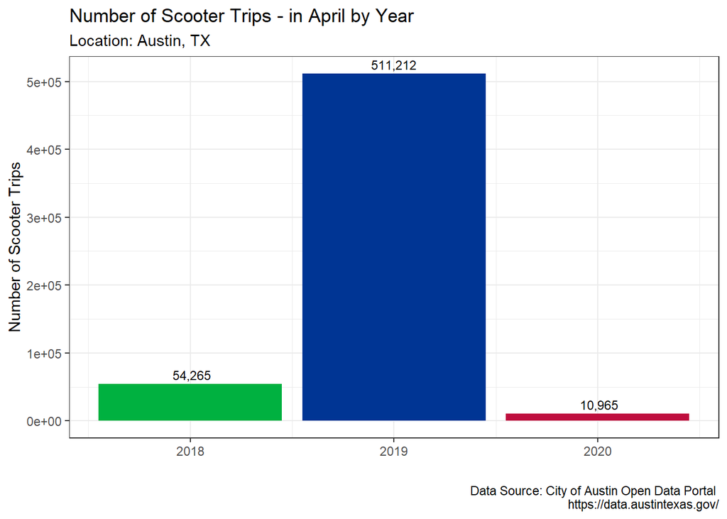

```r
ggplot(count_by_year, aes(x = year, y = count, fill = as.character(year))) +
  geom_col() +
  geom_text(aes(label = format(count, big.mark = ",")), vjust = -0.45, size = 3) +
  labs(title = "Number of Scooter Trips - in April by Year",
       subtitle = loc,
       caption = data_src) +
  ylab("Number of Scooter Trips") +
  xlab("") +
  scale_fill_manual(values = col3, guide = FALSE)
```

```r
#av.note: need to fix exponential notation on y-axis
```

## Number of Scooter Trips by Day - in April by Year

```r
count_by_year_day <- df %>%
  filter(day_of_month != 31) %>%
  group_by(year, month, day_of_month, weekend) %>%
  summarise(count = n()) %>%
  arrange(year, day_of_month)
```

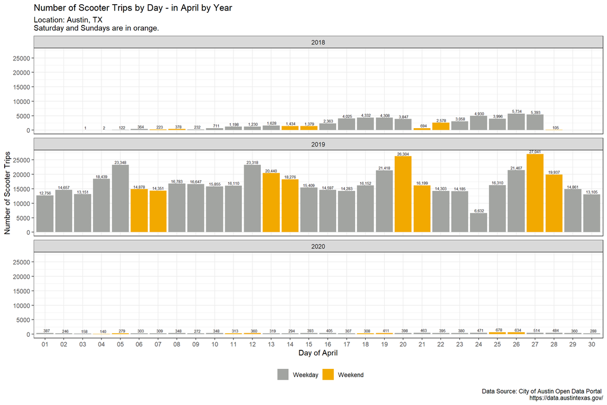

```r
ggplot(count_by_year_day, aes(x = day_of_month, y = count, fill = as.factor(weekend))) +
  geom_col() +
  geom_text(aes(label = format(count, big.mark = ",")), vjust = -0.3, size = 2) +
  facet_wrap(vars(year), nrow = 3, scales = "fixed") +
  labs(title = "Number of Scooter Trips by Day - in April by Year",
       subtitle = paste0(loc, " \nSaturday and Sundays are in orange."),
       caption = data_src) +
  ylab("Number of Scooter Trips") +
  xlab("Day of April") +
  theme(legend.position = "bottom") +
  scale_fill_manual(values = col2, labels = c("Weekday", "Weekend"), name = "") +
  scale_y_continuous(breaks = seq(0, 30000, 5000))
```

## Number of Scooter Trips by Day of Week - in April by Year

In April 2018, the data suggest that riding a scooter on the weekend wasn’t a frequent occurance compared to weekdays.

In April 2019, Fridays and Saturdays were the most popular days to ride a scooter. Wednesdays had the lowest number of trips.

In April 2020, there seems to be a pretty level lack of scooter ridership on any day of the week. Though it should be noted that Fridays received the fewest trips out of all of the days of the week.

```r
dow_levels = c("Monday", "Tuesday", "Wednesday", "Thursday", "Friday", "Saturday", "Sunday")

count_dayofweek <- df %>%
  filter(day_of_month != 31) %>%
  group_by(year, day_of_week_str) %>%
  summarise(count = n()) %>%
  arrange(year, day_of_week_str) %>%
  mutate(day_of_week = factor(day_of_week_str, levels = dow_levels))
```

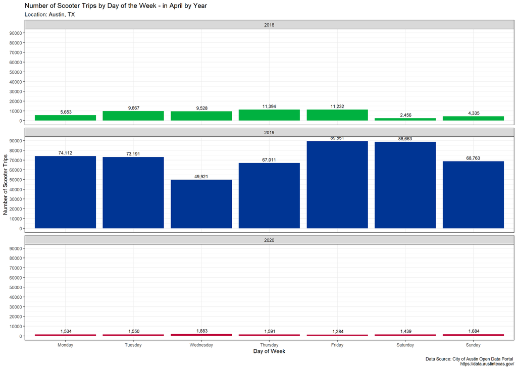

```r
ggplot(count_dayofweek, aes(x = day_of_week, y = count, fill = as.character(year))) +
  geom_col() +
  geom_text(aes(label = format(count, big.mark = ",")), vjust = -0.5, size = 3) +
  facet_wrap(vars(year), nrow = 3, scales = "fixed") +
  labs(title = "Number of Scooter Trips by Day of the Week - in April by Year",
       subtitle = loc,
       caption = data_src) +
  ylab("Number of Scooter Trips") +
  xlab("Day of Week") +
  scale_y_continuous(breaks = seq(0, 1500000, 10000)) +
  scale_fill_manual(values = col3, guide = FALSE)
```

```r
#av.note: need to fix where Friday annotation is getting cut off
```